# Applied machine learning

Pre-processing with `recipes`

Dr. Joseph P. Yurko

Fall 2020 Semester

## Overview

This example is based on the detailed discussion in Chapter 3 of [HOML](https://bradleyboehmke.github.io/HOML/engineering.html) and a [tutorial of the recipes package](https://rsample.tidymodels.org/articles/Applications/Recipes_and_rsample.html). I’ve added a little to it, but please see those two links for more details.

This example goes through a realistic set of pre-processing steps using the Ames Housing data set. You will often need to manipulate, transform, and modify your variables before building succesful models, even after creating the contextualized analytics ready data! These series of actions are collectively known as **pre-processing** or **feature engineering**. The variables in the Ames Housing Data set can be mutated many different ways. So if you want to get extra practice pre-processing, the Ames Housing Data set is a great place to start.

Let’s go ahead and load in some of the packages we will use. We will continue to use `dplyr` and `ggplot2`. We will access the Ames Housing Data from the `AmesHousing` package. We will use additional packages in this demo, but I will make mention of them when we do.

```r
library(dplyr)
```

```r
library(ggplot2)
library(AmesHousing)
```

## Load data

The data set is loaded in the cell below using the `make_ames()` function.

```r
ames <- make_ames()
```

## Missings

There are multiple ways to build a graphic to display missing values. The relatively new `visdat` package provides useful graphics that can be created with single lines of code. The `visdat::vis_mis()` is a function which graphically displays the missings in a data set. I used to make such a figure manually, but now I just use the `visdat` library for such visualizations.

Please download and install the `visdat` package before proceeding. The code chunk below uses the `visdat::vis_mis()` function to visualize the missing observations in our data set. However, as we can see below there are no missings! The data is “complete”. Note, the `theme()` call is included to change the font size of the horizontal axis because there are simply so many variables to this data set it can be difficult to read the variable names!

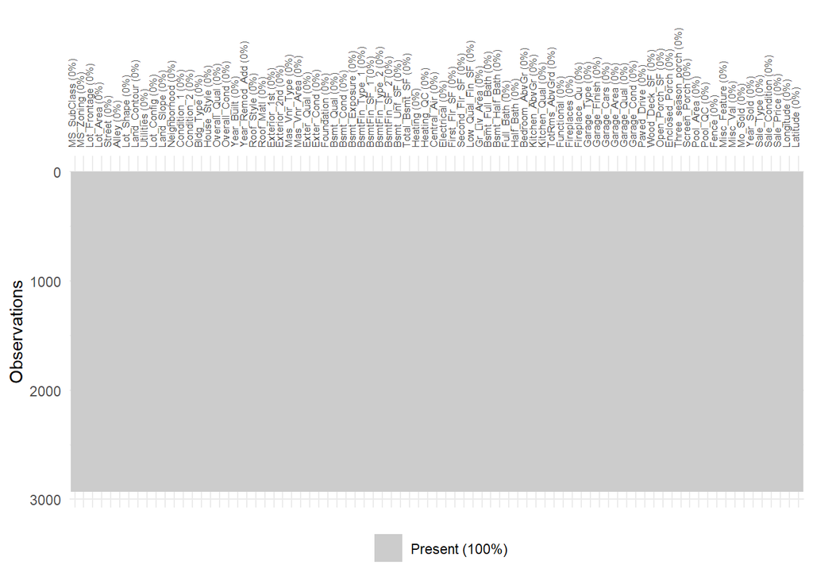

```r
visdat::vis_miss(ames) +
  theme(axis.text.x = element_text(size = 6.5, angle = 90))
```

We loaded in the `ames` data via the `AmesHousing::make_ames()` function. This function starts with a larger, more complex data set and performs some pre-processing steps for us behind the scenes! It removes deals with missings for us so we can work with a slightly easier data set. To show what missigs more commonly look like in real applications, we will recreate the missing visualization but this time with the `AmesHousing::ames_raw` data.

As we can see in the figure generated below, about 6% of all entries have missing values. However it seems that most of the missings are dominated by a relatively small number of variables. The `cluster=TRUE` argument to `visdat::vis_miss()` uses an unsupervised learning technique (a hierarchical clustering algorithm) to group the observations together based on their missings.

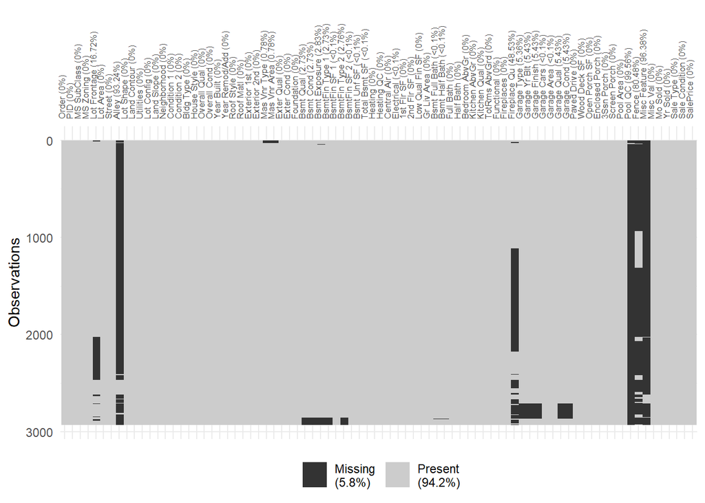

```r
visdat::vis_miss(AmesHousing::ames_raw, cluster=TRUE) +
  theme(axis.text.x = element_text(size = 6.5, angle = 90))
```

The rest of this report will use the once pre-processed `make_ames()` data, which has the missings already removed. I wanted to include the above figure to demonstrate how we can quickly look for missing patterns in our data.

## Small example - EDA

Because there are so many features in the Ames data set, we will concentrate on just a handful. These specific variables are those described in the [tutorial of the recipes package](https://rsample.tidymodels.org/articles/Applications/Recipes_and_rsample.html). The 4 input variables we will start with are selected from the complete data set, along with the response of interest, `Sale_Price`, in the code chunk below.

```r
my_ames <- ames %>%
  dplyr::select(Sale_Price, Neighborhood, House_Style, Year_Sold, Lot_Area)
```

Let’s use the `visdat` package again to visualize the data types associated with our subset of features. The `visdata::visdat()` function will also visualize missings, but the colors now provide a visual reference for the data type. We already know our `make_ames()` data set has no missings. As shown below, we have 2 data types: factor and integer. A factor is `R`’s nomeclature for discrete or categorical variables. Thus, the `Neighborhood` and `House_Style` variables are discrete. The other three variables in our small example data set are numbers, but they do not have decimal points since they are integer data types.

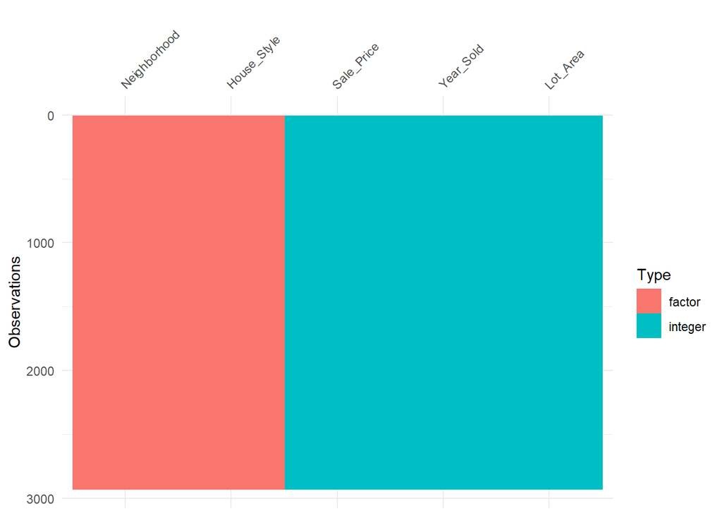

```r
visdat::vis_dat(my_ames)
```

### EDA - inputs

Exploratory Data Analysis (EDA) is an important step of any data analysis project. Even if we plan on building numerous predictive models and using those models to identify important variables, we **must** first go through the data ourselves. We need to develop an intuition about our data and understand what it contains. Only then will we have sufficient context to interpret why models behave the way they do. Specifically, EDA can help us understand if we need to transform the variables so they are more suitable for modeling.

Let’s start by looking through a quick summary our variables with the `summary()` function.

```r
my_ames %>% summary()
```

```
##    Sale_Price                 Neighborhood            House_Style
##  Min.   : 12789   North_Ames        : 443   One_Story       :1481
##  1st Qu.:129500   College_Creek     : 267   Two_Story       : 873
##  Median :160000   Old_Town          : 239   One_and_Half_Fin: 314
##  Mean   :180796   Edwards           : 194   SLvl            : 128
##  3rd Qu.:213500   Somerset          : 182   SFoyer          :  83
##  Max.   :755000   Northridge_Heights: 166   Two_and_Half_Unf:  24
##                   (Other)           :1439   (Other)         :  27
##    Year_Sold       Lot_Area
##  Min.   :2006   Min.   :  1300
##  1st Qu.:2007   1st Qu.:  7440
##  Median :2008   Median :  9436
##  Mean   :2008   Mean   : 10148
##  3rd Qu.:2009   3rd Qu.: 11555
##  Max.   :2010   Max.   :215245
##
```

We see the number of rows (counts) associated with the levels (unique values) of the discrete variables. The `(Other)` level represents a lumping or grouping of lower frequency levels compared with the ones printed to screen. The `Neighborhood` variable has roughly half of the rows associated with other levels. The `levels()` function will tell us the unique values associated with a factor variable, as we can see below there are 29 levels!

```r
levels(my_ames$Neighborhood)
```

```
##  [1] "North_Ames"
##  [2] "College_Creek"
##  [3] "Old_Town"
##  [4] "Edwards"
##  [5] "Somerset"
##  [6] "Northridge_Heights"
##  [7] "Gilbert"
##  [8] "Sawyer"
##  [9] "Northwest_Ames"
## [10] "Sawyer_West"
## [11] "Mitchell"
## [12] "Brookside"
## [13] "Crawford"
## [14] "Iowa_DOT_and_Rail_Road"
## [15] "Timberland"
## [16] "Northridge"
## [17] "Stone_Brook"
## [18] "South_and_West_of_Iowa_State_University"
## [19] "Clear_Creek"
## [20] "Meadow_Village"
## [21] "Briardale"
## [22] "Bloomington_Heights"
## [23] "Veenker"
## [24] "Northpark_Villa"
## [25] "Blueste"
## [26] "Greens"
## [27] "Green_Hills"
## [28] "Landmark"
## [29] "Hayden_Lake"
```

Alternatively, we can use the `dplyr` function `count()` to not only tell us the unique values of any variable (numeric, integer, character, or factor), but also the number of rows associated with each value. The result of `count()` is a tibble, so it is piped into the `knitr::kable()` function to produce the “nice” looking table for the HTML render. As we can see below, there are some unique values with very few observations. One level only has a single row associated with it!

```r
my_ames %>%
  count(Neighborhood) %>%
  knitr::kable()
```

| Neighborhood | n |
| --- | --- |
| North_Ames | 443 |
| College_Creek | 267 |
| Old_Town | 239 |
| Edwards | 194 |
| Somerset | 182 |
| Northridge_Heights | 166 |
| Gilbert | 165 |
| Sawyer | 151 |
| Northwest_Ames | 131 |
| Sawyer_West | 125 |
| Mitchell | 114 |
| Brookside | 108 |
| Crawford | 103 |
| Iowa_DOT_and_Rail_Road | 93 |
| Timberland | 72 |
| Northridge | 71 |
| Stone_Brook | 51 |
| South_and_West_of_Iowa_State_University | 48 |
| Clear_Creek | 44 |
| Meadow_Village | 37 |
| Briardale | 30 |
| Bloomington_Heights | 28 |
| Veenker | 24 |
| Northpark_Villa | 23 |
| Blueste | 10 |
| Greens | 8 |
| Green_Hills | 2 |
| Landmark | 1 |

We can also visualize the counts with a bar graph instead. The levels of `Neighborhood` have already been ordered so a `geom_bar()` geom will produce a figure with ascending bar graph height. The code chunk below creates the bar graph, and uses `coord_flip()` so that the level values (the names of the neighborhoods) appear horizontally. This makes it easy to tell that 11 out of the 29 levels have less than 50 observations each!

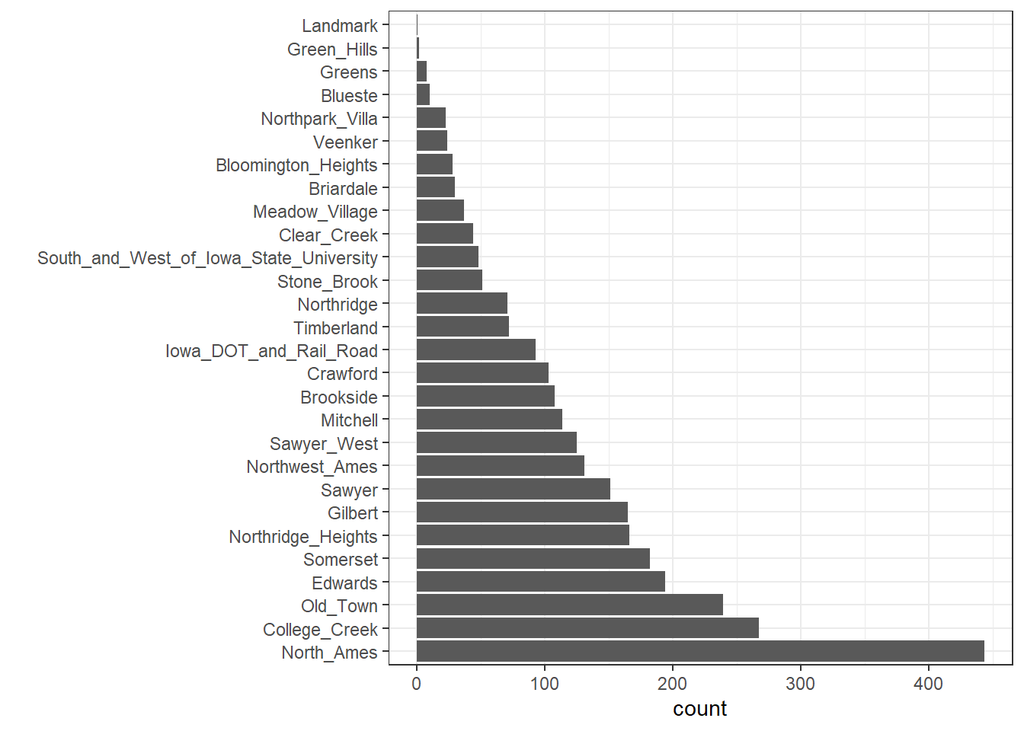

```r
my_ames %>%
  ggplot(mapping = aes(x = Neighborhood)) +
  geom_bar() +
  coord_flip() +
  labs(x = "") +
  theme_bw()
```

Let’s now take a look at the `House_Style` variable. Again we can use `count()` to give us the unique values and number of rows associated with each value. Because there are just 8 levels of the `House_Style` factor, the tibble is shown directly rather than calling `knitr::kable()`.

```r
my_ames %>%
  count(House_Style)
```

```
## # A tibble: 8 x 2
##   House_Style          n
##   <fct>            <int>
## 1 One_and_Half_Fin   314
## 2 One_and_Half_Unf    19
## 3 One_Story         1481
## 4 SFoyer              83
## 5 SLvl               128
## 6 Two_and_Half_Fin     8
## 7 Two_and_Half_Unf    24
## 8 Two_Story          873
```

As we can see above, the counts are not ordered. The levels are displayed in alphabetical order. Thus if we were to plot the counts with `geom_bar()` we would not see the bar graph heights sequentially increasing as we saw with `Neighborhood`, as shown below.

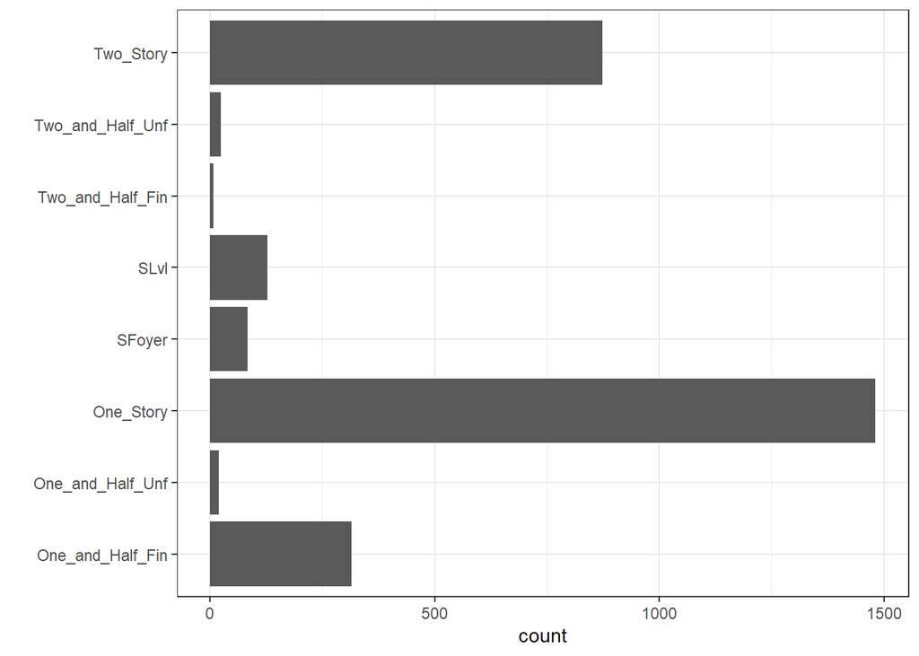

```r
my_ames %>%
  ggplot(mapping = aes(x = House_Style)) +
  geom_bar() +
  coord_flip() +
  labs(x = "") +
  theme_bw()
```

We can reorder the levels so that they are displayed based on their count or frequency order. The `forcats::fct_infreq()` function allows us to perform that operation. If you installed `tidyverse` you already have the `forcats` package. It is a useful library for working with categorical and discrete variables in `R`. Please see the [forcats tidyverse page](https://forcats.tidyverse.org/) for more information. The code chunk below creates the bar graph again but this time after modifying the `House_Style` so it is ordered by the level frequency. As shown below, 5 of the levels have less than 250 observations each.

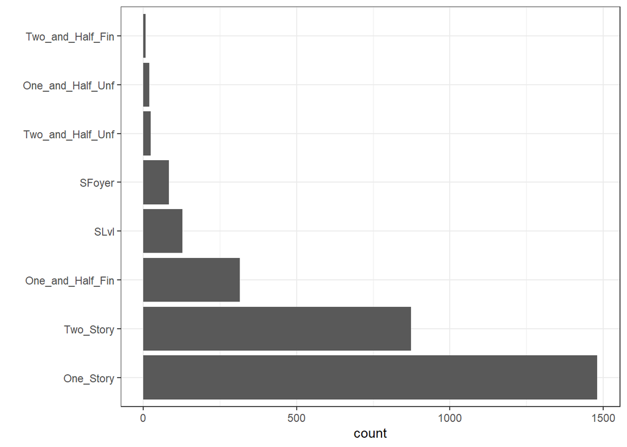

```r
my_ames %>%
  mutate(House_Style = forcats::fct_infreq(House_Style)) %>%
  ggplot(mapping = aes(x = House_Style)) +
  geom_bar() +
  coord_flip() +
  labs(x = "") +
  theme_bw()
```

We can display the the proportion of observations in a bar graph instead of the count by assigning the `y` aesthetic in `geom_bar()` to be `stat(prop)` and setting the `group` aesthetic to be `1`. The figure below makes it clear that 5 levels account for less than 5% of the observations each.

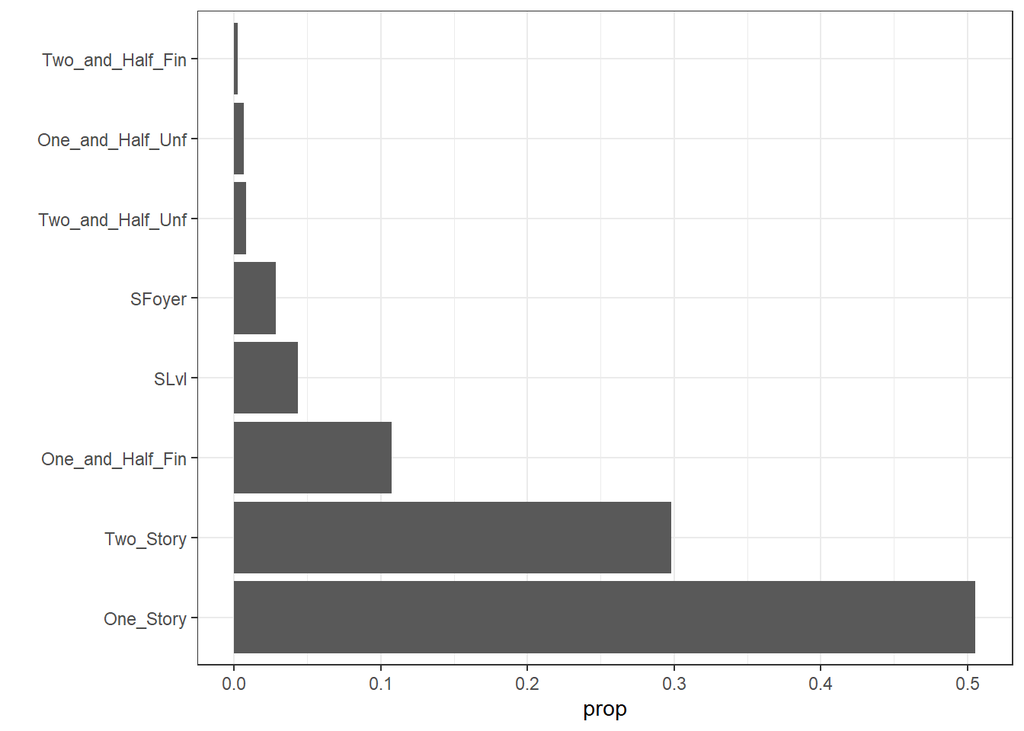

```r
my_ames %>%
  mutate(House_Style = forcats::fct_infreq(House_Style)) %>%
  ggplot(mapping = aes(x = House_Style, y = stat(prop), group = 1)) +
  geom_bar() +
  coord_flip() +
  labs(x = "") +
  theme_bw()
```

We are looking at the counts and proportions associated with each level (unique value) of factors (discrete variables) because it is important to consider how we can work with such low frequency values. We have already discussed resampling and how it can help guard against overfitting. **Low frequency levels of discrete factors pose a substantial challenge for resampling**. For example, let’s consider the 5 levels of `House_Style` that occur less than 5% of the time. If we use 5-fold cross-validation, roughly 20% of the data will be held out as a test set in each fold. That means there’s a chance **all** of the observations of a particular level will be selected for the test set in a fold. How can the model trained on the training set deal with such a prediction task? The low frequency levels would quite literally be outside the training set.

A common approach for dealing with such low frequency levels is to “lump” or “group” them together into an **OTHER** category. Other is a catch-all for any other category associated with that factor. We will give up the ability to resolve differences between such low frequency levels, and so we should consider the implications of our pre-processing action. For example, if we know there are a few levels that we are particularly interested in which are low frequency, we should consider alternative approaches. Stratified cross-validation is one such approach we could consider, where we would stratify based on the factor of interest. The “lumping” into Other is rather simple, but can be useful as an initial operation when beginning a modeling exercise.

Let’s go ahead and create the lumped “other” level for both `Neighorhood` and `House_Style`. The `forcats::fct_lump_prop()` function will do that for us. The heat map below visualizes the proportion associated with each combination of the levels in `Neighborhood` and `House_Style` after we performed the lumping operation. Note that the proportion was computed by piping the data into `count()` and then using a `mutate()` call to divide the `n` column by the `sum(n)` (the total number of observations). The text `color` aesthetic displayed on the heat map was mapped to the proportion to help make it easier to read the text display on the changing fill background associated with the combinations. As we can see below, the “lumping” operation for the `Neighborhood` will be difficult since there are a considerable fraction of observations that are accounted for by “other”. The lumping operation for `House_Style` however appears to be more appropriate since it’s still a small fraction of the overall observations.

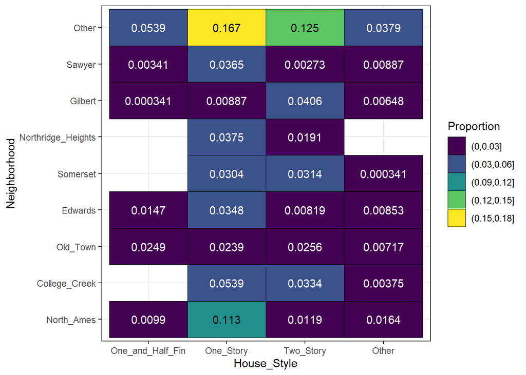

```r
my_ames %>%
  mutate(House_Style = forcats::fct_lump_prop(House_Style, 0.05),
         Neighborhood = forcats::fct_lump_prop(Neighborhood, 0.05)) %>%
  count(House_Style, Neighborhood) %>%
  mutate(prop_total = n / sum(n)) %>%
  ggplot(mapping = aes(x = House_Style, y = Neighborhood)) +
  geom_tile(mapping = aes(fill = cut(prop_total,
                                     breaks = seq(0, 0.18, by = 0.03))),
            color = "black") +
  geom_text(mapping = aes(label = signif(prop_total, 3),
                          color = prop_total < 0.09)) +
  scale_fill_viridis_d("Proportion") +
  scale_color_manual(guide = FALSE,
                     values = c("TRUE" = "white",
                                "FALSE" = "black")) +
  theme_bw()
```

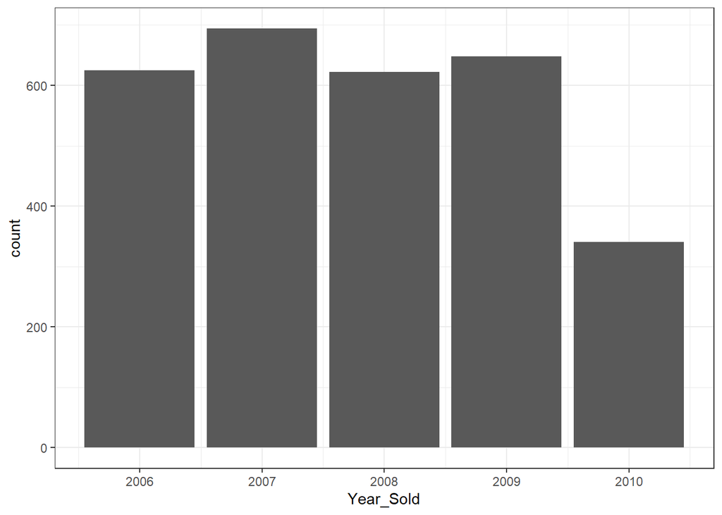

```r
my_ames %>%
  ggplot(mapping = aes(x = Year_Sold)) +
  geom_bar() +
  theme_bw()
```

The remaining input in our small data set example is `Lot_Area`. We saw that it is an integer earlier, so let’s look at it’s histogram to get an idea about the shape.

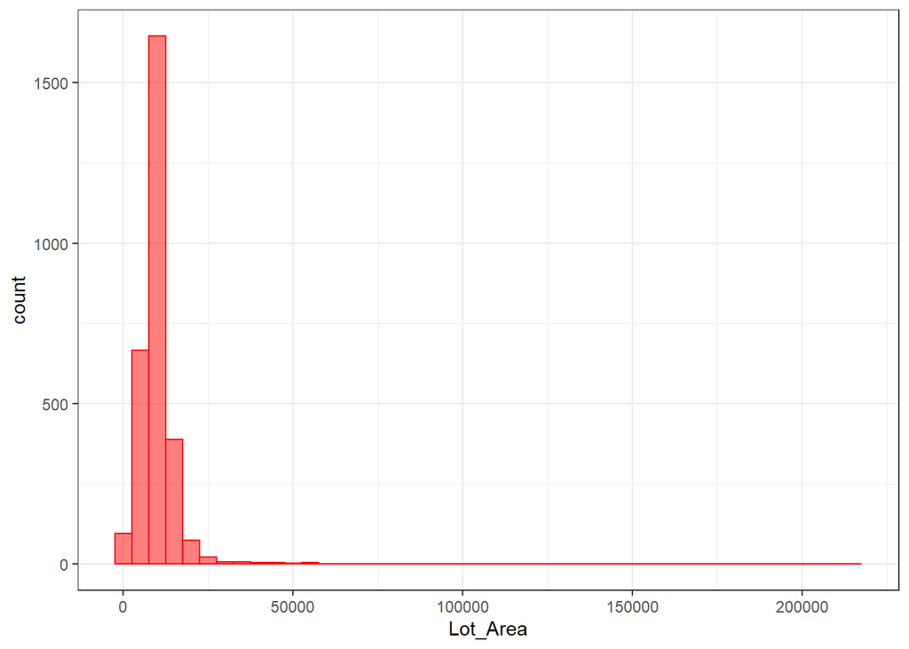

```r
my_ames %>%
  ggplot(mapping = aes(x = Lot_Area)) +
  geom_histogram(binwidth = 5000, color = "red", fill = "red", alpha = 0.5) +
  theme_bw()
```

As shown above, the `Lot_Area` has an exceedingly long tail. Values of greater than 40000 appear to be very low frequency. Let’s take a look at the empirical CDF to understand the proportion of `Lot_Area` values. Horizontal lines at 0.8 and 0.95 are displayed for reference. As we can see, 95% of the `Lot_Area` observations have values less than 25000. The values greater than 25000 are very low frequency.

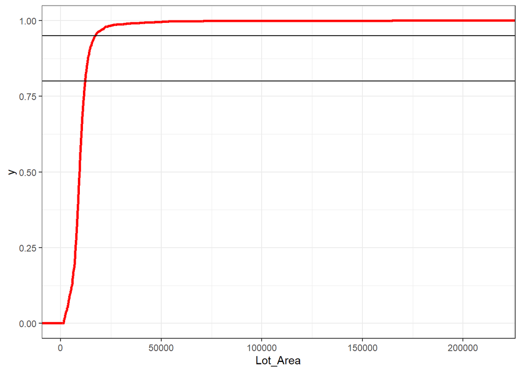

```r
my_ames %>%
  ggplot(mapping = aes(x = Lot_Area)) +
  stat_ecdf(color = "red", size = 1.15) +
  geom_hline(yintercept = c(0.8, 0.95), color = "black") +
  theme_bw()
```

We can remove the skew of the `Lot_Area` distribution through statistical transformations. A simple approach is to take the natural log or another common value like log base 2 or log base 10. We could also consider trying to find an “optimal” transformation via a power transformation like Box-Cox (or the more general Yeo-Johnson) transformation. The [HOML](https://bradleyboehmke.github.io/HOML/engineering.html) book and the Applied Predictive Modeling book discuss the Box-Cox transformation in more detail. For now, we will use a natural log-transformation on `Lot_Area`. As shown in the histogram below, the extreme tail has been “compressed” by the natural log. The observations are all of the same order of magnitude. Removing the skew of an input can be especially important for linear models.

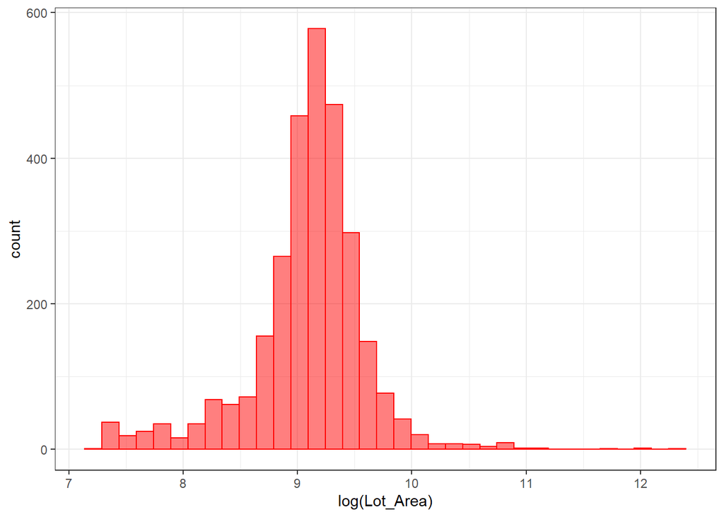

```r
my_ames %>%
  ggplot(mapping = aes(x = log(Lot_Area))) +
  geom_histogram(bins = 35, color = "red", fill = "red", alpha = 0.5) +
  theme_bw()
```

### EDA - response

Let’s now start to look at the response, the `Sale_Price`. We will start with a histogram which as shown below reveals that `Sale_Price` covers a large range of values.

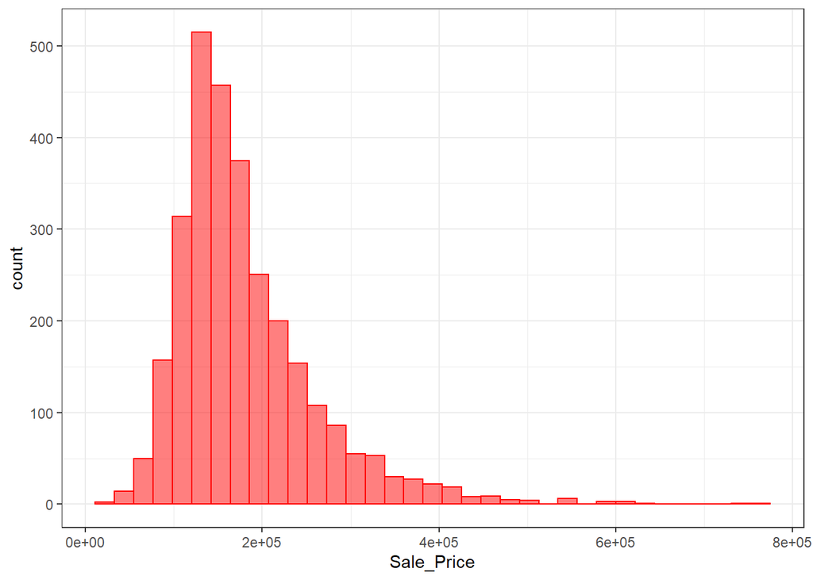

```r
my_ames %>%
  ggplot(mapping = aes(x = Sale_Price)) +
  geom_histogram(bins = 35, color = "red", fill = "red", alpha = 0.5) +
  theme_bw()
```

The `Sale_Price` is not symmetric. It is skewed with a rather long tail towards high values. Let’s use the `quantile()` function to print out the quintiles (0, 0.2, 0.4, 0.6, 0.8, 1.0). The quintiles represent 20% or 1/5th of the data. As the print out below shows, the 0.8 quantile (80th percentile) is equal to about 230000. Thus, 80% of the observations have sale prices less than 230000. The largest values around and greater than 500000 correspond to half a million dollar homes or more. They represent the wealthiest homes in the data set. Note that the 0% and 100% quantiles are just the minimum and maximum values in the data set.

```r
quantile(my_ames$Sale_Price, probs = seq(0, 1, by = 0.2))
```

```
##     0%    20%    40%    60%    80%   100%
##  12789 124000 146500 178536 230000 755000
```

Understanding our response variable distribution helps us to know if we should consider removing the skew, making the distribution look more like a Normal. We already discussed several approaches for doing this with inputs before. Removing the skew of response variables can be useful for linear models for reasons we will see in a few weeks.

However, a practical aspect of the long-tail in the distribution is understanding the weight of errors. If we incorrectly predict the sale price of a $750,000 home by $20,000, that’s a relative error of less than 3%. However, if we incorrectly predict the price of $100,000 home by $20,000 that’s a relative error of 20%! A transformation of the output could be useful to help make sure the errors are more consistent across the range of response. I find this is an important consideration whenever the response ranges over an order of magnitude or more. The `Sale_Price` variable covers nearly 2 orders of magnitude. Thus, we should consider using a log-transformation for the response. The Ames Housing data typically uses a log-base 10 transformation.

Let’s now look at histogram of the `log10()` transformation of the `Sale_Price`. We see that all of the response values are single digits over a fairly narrow range.

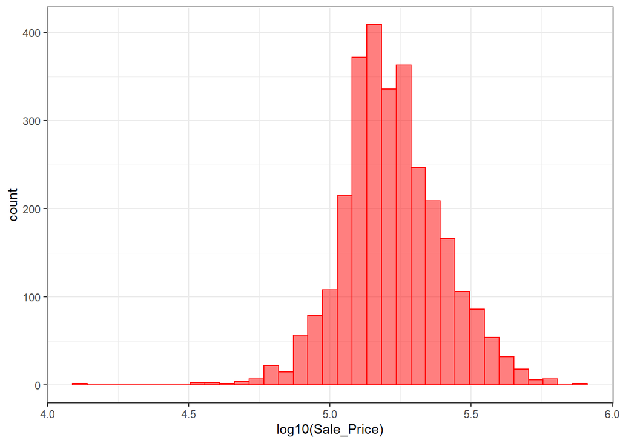

```r
my_ames %>%
  ggplot(mapping = aes(x = log10(Sale_Price))) +
  geom_histogram(bins = 35, color = "red", fill = "red", alpha = 0.5) +
  theme_bw()
```

Let’s now start to look at the relationship between the response and the inputs. We will first consider the distribution of the log10 transformed `Sale_Price` with respect to each `Year_Sold`. The financial crisis of 2007-2008 occurred within this data set, so let’s check to see if there is a considerable change before and after that point in time. As shown below, there really does not seem to be a change in the log10 transformed sale price across the years. Things seem pretty stable.

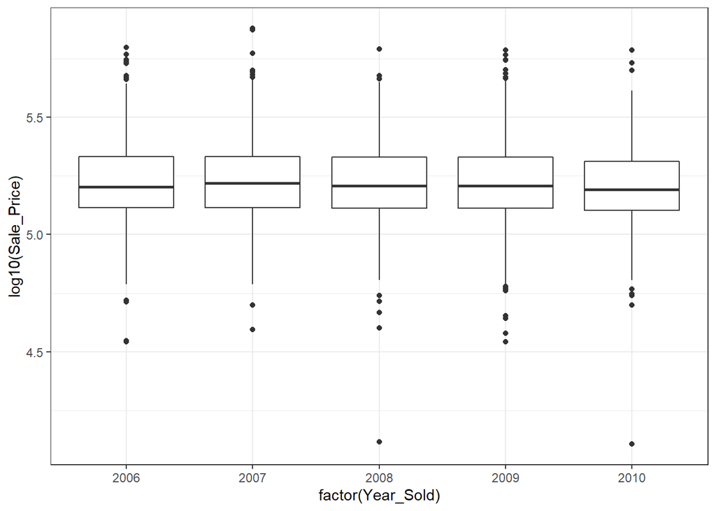

```r
my_ames %>%
  ggplot(mapping = aes(x = factor(Year_Sold),
                       y = log10(Sale_Price))) +
  geom_boxplot() +
  theme_bw()
```

Let’s now break up by the `House_Style`, including the “lumped” other category. Within each `Year_Sold` the style or type of House clearly has an impact on the sale price.

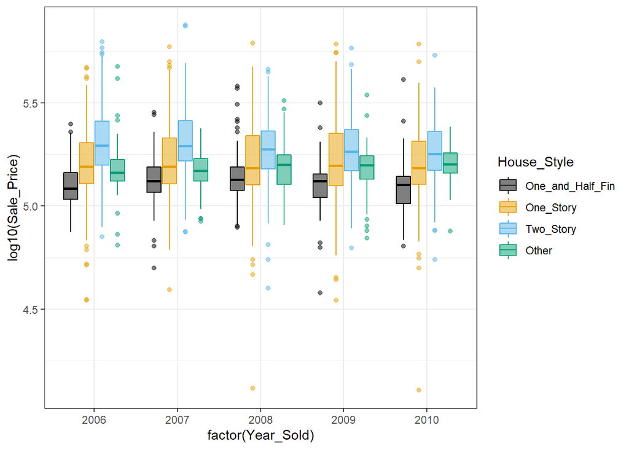

```r
my_ames %>%
  mutate(House_Style = forcats::fct_lump_prop(House_Style, 0.05),
         Neighborhood = forcats::fct_lump_prop(Neighborhood, 0.05)) %>%
  ggplot(mapping = aes(x = factor(Year_Sold),
                       y = log10(Sale_Price))) +
  geom_boxplot(mapping = aes(fill = House_Style,
                             color = House_Style),
               alpha = 0.5) +
  ggthemes::scale_color_colorblind() +
  ggthemes::scale_fill_colorblind() +
  theme_bw()
```

We will use facets to help visualize the effect of `Neighborhood`. Each facet in the figure below shows how the log10 transformed `Sale_Price` changes across years and `House_Style` categories. As we can see below, the relationship between the `House_Style` levels and the sale price depends on the `Neighorhood` value. For example, the most expensive homes in `Old_Town` tend to be the “other” `House_Style`. There are also values of `Neighborhood` which do not have all of the levels of `House_Style` present.

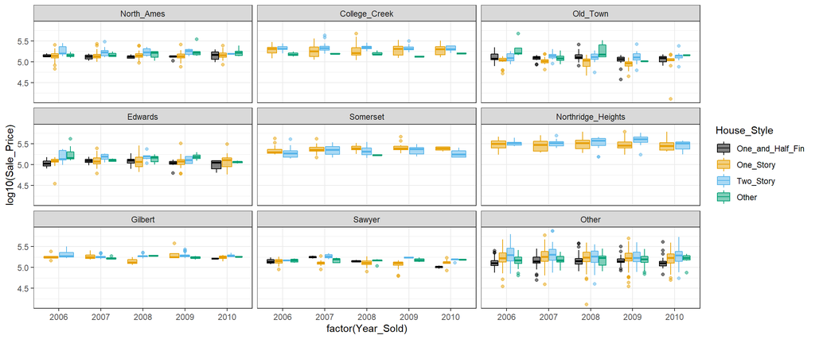

```r
my_ames %>%
  mutate(House_Style = forcats::fct_lump_prop(House_Style, 0.05),
         Neighborhood = forcats::fct_lump_prop(Neighborhood, 0.05)) %>%
  ggplot(mapping = aes(x = factor(Year_Sold),
                       y = log10(Sale_Price))) +
  geom_boxplot(mapping = aes(fill = House_Style,
                             color = House_Style),
               alpha = 0.5) +
  facet_wrap(~Neighborhood) +
  ggthemes::scale_color_colorblind() +
  ggthemes::scale_fill_colorblind() +
  theme_bw()
```

Let’s look at a scatter plot between the natural log of `Lot_Area` and the log10 of `Sale_Price` while accounting for the discrete variables. We will use `facet_grid()` with the horizontal facets controlled by `Neighborhood` and the vertical facets controlled by `Year_Sold`. The color will be still set by the `House_Style`. There are `Neighborhood` values where the `log10(Sale_Price)` appears to have a linear relationshipw with `log(Lot_Area)`. However, it should be clear that such a relationship depends on the type of house and the neighorhood. We should therefore expect interactions to be an important aspect of a model.

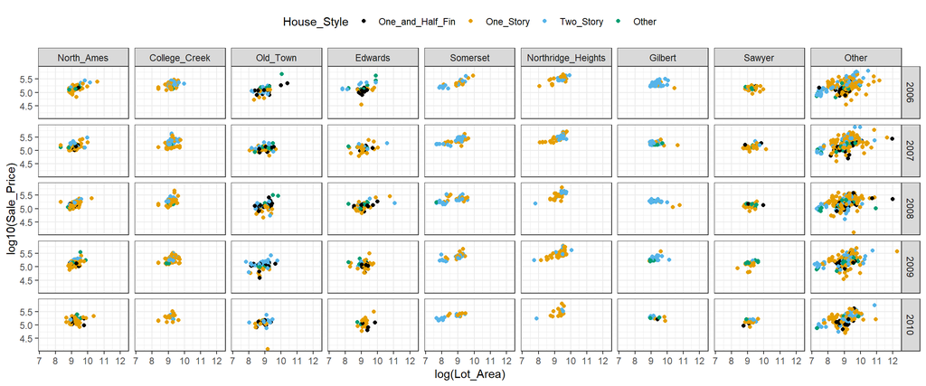

```r
my_ames %>%
  mutate(House_Style = forcats::fct_lump_prop(House_Style, 0.05),
         Neighborhood = forcats::fct_lump_prop(Neighborhood, 0.05)) %>%
  ggplot(mapping = aes(x = log(Lot_Area),
                       y = log10(Sale_Price))) +
  geom_point(mapping = aes(color = House_Style)) +
  facet_grid(Year_Sold~Neighborhood) +
  ggthemes::scale_color_colorblind() +
  ggthemes::scale_fill_colorblind() +
  theme_bw() +
  theme(legend.position = "top")
```

## Pre-processing

The EDA we just performed revealed several important pieces of information before we build our models. However, certain actions should **not** be performed ahead of resampling. The “lumping” of the low frequency factor levels into “other” depends on the data set. When we use cross-validation, we are trying to approximate the behavior of a modeling “in production”. The fold hold-out sets represent “completely new data”. Thus, if we lump the categories into “other” before resampling we are actually using ALL of the data to make that decision.

The correct way to perform any type of pre-processing action is to perform it relative to an individual fold’s training set. Even simple pre-processing steps like centering (subtracting out the emprical average) and scaling (usually divide by the empirical standard deviation) should be relative to each fold’s training set.

Thus, rather than performing these actions manually we will create a “blueprint” of the actions we wish to perform. The `recipes` package was created with this very idea in mind. The goal is to create a “recipe” or “blueprint” of pre-processing steps we want to perform. The steps are followed in a particular order, within each resample fold. These way we can minimize the impact of “data leakage” and have a more representative estimate to the model behavior on new data.

Chapter 3 of [HOML](https://bradleyboehmke.github.io/HOML/engineering.html) provides a more detailed overview of this idea.

### `recipes`

For now, let’s just see how to use the `recipes` package to perform the desired pre-processing steps. First, we must load in the library. If you do not have `recipes` it’s best to download the `tidymodels` meta-package. That way you get the entire suite of `tidymodels` tools.

```r
library(recipes)
```

We create the recipe first with a formula. The formula allows `recipe()` to understand the roles of the variables, which are outputs and which are predictors. The recipe given below follows the major steps we discussed earlier. The response is log10 transformed. The low frequency levels of the factors are “lumped” to “other”. The `Lot_Area` is transformed, but below I use the Box-Cox transformation like the [tutorial of the recipes package](https://rsample.tidymodels.org/articles/Applications/Recipes_and_rsample.html). The predictors are all standardized via centering and scaling. The one step we did not discuss yet is the creation of the dummy variables. We will discuss this operation later in the semester.

```r
small_recipe <- recipe(Sale_Price ~ Neighborhood + House_Style + Year_Sold + Lot_Area,
                       data = my_ames) %>%
  step_log(Sale_Price, base = 10) %>%
  step_other(Neighborhood, House_Style, threshold = 0.05) %>%
  step_dummy(all_nominal()) %>%
  step_BoxCox(Lot_Area) %>%
  step_center(all_predictors()) %>%
  step_scale(all_predictors())
```

Printing out our `small_recipe` does **NOT** produce a data set. Instead it simply gives a series of steps (actions) to be performed.

```r
small_recipe
```

```
## Data Recipe
##
## Inputs:
##
##       role #variables
##    outcome          1
##  predictor          4
##
## Operations:
##
## Log transformation on Sale_Price
## Collapsing factor levels for Neighborhood, House_Style
## Dummy variables from all_nominal()
## Box-Cox transformation on Lot_Area
## Centering for all_predictors()
## Scaling for all_predictors()
```

We must first prepare the recipe to be applied with the `prep()` function.

```r
small_recipe_on_data <- prep(small_recipe, training = my_ames)
```

Printing out the prepared recipe now reveals it “knows” the size of the data it is prepared for.

```r
small_recipe_on_data
```

```
## Data Recipe
##
## Inputs:
##
##       role #variables
##    outcome          1
##  predictor          4
##
## Training data contained 2930 data points and no missing data.
##
## Operations:
##
## Log transformation on Sale_Price [trained]
## Collapsing factor levels for Neighborhood, House_Style [trained]
## Dummy variables from Neighborhood, House_Style [trained]
## Box-Cox transformation on Lot_Area [trained]
## Centering for Year_Sold, Lot_Area, ... [trained]
## Scaling for Year_Sold, Lot_Area, ... [trained]
```

However, we still do not have a data set! To “extract” the data we have to use the `juice()` function (the `R` community likes its puns). After “juicing” the data, and printing out the first six rows we see that our actions have created more features than the original set of 4 inputs! We learn why that is later in the term.

```r
juice(small_recipe_on_data) %>% head()
```

```
## # A tibble: 6 x 14
##   Year_Sold Lot_Area Sale_Price Neighborhood_Co~ Neighborhood_Ol~
##       <dbl>    <dbl>      <dbl>            <dbl>            <dbl>
## 1      1.68    2.70        5.33           -0.317           -0.298
## 2      1.68    0.506       5.02           -0.317           -0.298
## 3      1.68    0.930       5.24           -0.317           -0.298
## 4      1.68    0.423       5.39           -0.317           -0.298
## 5      1.68    0.865       5.28           -0.317           -0.298
## 6      1.68    0.197       5.29           -0.317           -0.298
## # ... with 9 more variables: Neighborhood_Edwards <dbl>,
## #   Neighborhood_Somerset <dbl>, Neighborhood_Northridge_Heights <dbl>,
## #   Neighborhood_Gilbert <dbl>, Neighborhood_Sawyer <dbl>,
## #   Neighborhood_other <dbl>, House_Style_One_Story <dbl>,
## #   House_Style_Two_Story <dbl>, House_Style_other <dbl>
```

## Realistic application

As stated earlier though, we are more interested in creating a recipe to apply within each of the folds of our desired resampling operation. We would only extract the the prepared data (via `juice()`) if we wanted to perform the resampling operations ourselves (which happens in custom models!), or if we wanted to inspect the prepared features, or if we wanted to share the prepared data. As you will see later in the semester, most model objects in `R` store the pre-processing operations they must perform when making predictions. So for those models we don’t even need to perform the preprocessing when predicting, it is taken care of behind the scenes.

We will now use the `recipe()` function to create the necessary pre-processing steps on the entire set of variables in the Ames Housing Data set. We will use the recipe object as the input to the `caret::train()` function instead of the formula. The pre-processing actions will consist of all of the steps described in the example from [HOML](https://bradleyboehmke.github.io/HOML/engineering.html). The recipe is saved to the `blueprint` object below.

```r
blueprint <- recipe(Sale_Price ~ ., data = ames) %>%
  step_nzv(all_nominal()) %>%
  step_integer(matches("Qual|Cond|QC|Qu")) %>%
  step_center(all_numeric(), -all_outcomes()) %>%
  step_scale(all_numeric(), -all_outcomes()) %>%
  step_dummy(all_nominal(), -all_outcomes(), one_hot = TRUE)
```

Printing to screen again reveals that we only have a set of instructions!

```r
blueprint
```

```
## Data Recipe
##
## Inputs:
##
##       role #variables
##    outcome          1
##  predictor         80
##
## Operations:
##
## Sparse, unbalanced variable filter on all_nominal()
## Integer encoding for matches("Qual|Cond|QC|Qu")
## Centering for all_numeric(), -all_outcomes()
## Scaling for all_numeric(), -all_outcomes()
## Dummy variables from all_nominal(), -all_outcomes()
```

Let’s now use the recipe with a k-nearest neighbor model. We will use `caret` to tune the number of nearest neighbors with a grid search. To save time our grid will search by 2 while the example in [HOML](https://bradleyboehmke.github.io/HOML/engineering.html) searched in increments of 1.

```r
library(caret)
```

We will use 5-fold cross-validation without repeats. And we specify our tuning grid.

```r
my_ctrl <- trainControl(method = "cv", number = 5)

k_grid <- expand.grid(k = seq(2, 25, by = 2))
```

The k-nearest neighbor model is trained and tuned with `caret::train()` below. There is no reason to specify the `preProcess` argument to `train()` because we used a recipe!

```r
set.seed(98123)
fit_knn <- train(blueprint, data = ames,
                 method = "knn",
                 metric = "RMSE",
                 tuneGrid = k_grid,
                 trControl = my_ctrl)
```

Our tuning results are displayed in the figure below to identify the optimal number of neighbors to use.

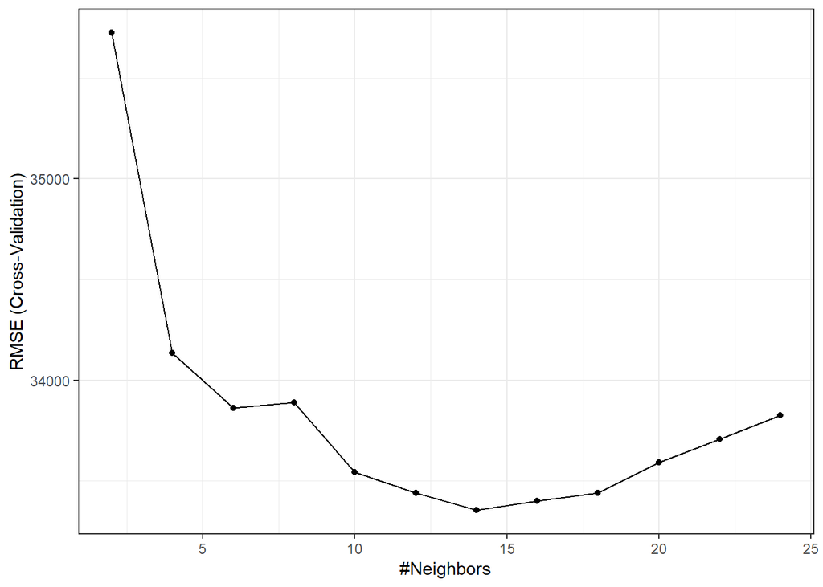

```r
ggplot(fit_knn) + theme_bw()
```